```python
from dsc80_utils import *
```

# Lecture 17 – Random Forests, Classifier Evaluation

## DSC 80, Summer 2024

## Final Exam 📝

- Will write the exam to take about 2 hours, so you'll have a lot of time to double check your work.
- Two 8.5"x11" cheat sheets allowed of your own creation (handwritten on tablet, then printed is okay.)
- Covers every lecture, lab, and project.
- Similar format to the midterm: mix of fill-in-the-blank, multiple choice, and free response.
  - WE use `pandas` fill-in-the-blank questions to test your ability to read and write code, not just write code from scratch, which is why they can feel tricker.
- Questions on final about pre-Midterm material will be marked as "M". Your Midterm grade will be the higher of your (z-score adjusted) grades on the Midterm and the questions marked as "M" on the final.

## Agenda

- Grid search
- Random forests
- Modeling with text features
- Classifier evaluation

## Decision Trees

### Example: Predicting Diabetes

```python
from sklearn.model_selection import train_test_split

diabetes = pd.read_csv(Path('data') / 'diabetes.csv')
X_train, X_test, y_train, y_test = (
    train_test_split(diabetes[['Glucose', 'BMI']], diabetes['Outcome'], random_state=1)
)
```

```python
fig = (
    X_train.assign(Outcome=y_train.astype(str))
            .plot(kind='scatter', x='Glucose', y='BMI', color='Outcome',
                  color_discrete_map={'0': 'orange', '1': 'blue'},
                  title='Relationship between Glucose, BMI, and Diabetes')
)
fig
```

[interactive chart not shown]

### Tree depth

Decision trees are trained by **recursively** picking the best split until:

- all "leaf nodes" only contain training examples from a single class (good), or
- it is impossible to split leaf nodes any further (not good).

By default, there is no "maximum depth" for a decision tree. As such, without restriction, decision trees tend to be very deep.

```python
from sklearn.tree import DecisionTreeClassifier

dt = DecisionTreeClassifier(max_depth=2, criterion='entropy')
dt.fit(X_train, y_train)

dt_no_max = DecisionTreeClassifier()
dt_no_max.fit(X_train, y_train)
```

```
DecisionTreeClassifier()
```

A decision tree fit on our training data has a depth of around 20! (It is so deep that `tree.plot_tree` errors when trying to plot it.)

```python
dt_no_max.tree_.max_depth
```

```
21
```

At first, this tree seems "better" than our tree of depth 2, since its training accuracy is much much higher:

```python
dt_no_max.score(X_train, y_train)
```

```
0.9913194444444444
```

```python
# Depth 2 tree.
dt.score(X_train, y_train)
```

```
0.765625
```

But recall, we truly care about **test set performance**, and this decision tree has **worse accuracy on the test set than our depth 2 tree**.

```python
dt_no_max.score(X_test, y_test)
```

```
0.71875
```

```python
# Depth 2 tree.
dt.score(X_test, y_test)
```

```
0.7760416666666666
```

### Decision trees and overfitting

- Decision trees have a tendency to overfit. **Why is that?**
- Unlike linear classification techniques (like logistic regression or SVMs), **decision trees are non-linear**.
  - They are also "non-parametric" – there are no $w^*$s to learn.
- While being trained, decision trees ask enough questions to effectively **memorize** the correct response values in the training set. However, the relationships they learn are often overfit to the noise in the training set, and don't generalize well.

```python
fig
```

[interactive chart not shown]

- A decision tree whose depth is not restricted will achieve 100% accuracy on any training set, as long as there are no "overlapping values" in the training set.
  - Two values overlap when they have the same features $x$ but different response values $y$ (e.g. if two patients have the same glucose levels and BMI, but one has diabetes and one doesn't).
- **One solution**: Make the decision tree "less complex" by limiting the maximum depth.

As tree depth increases, complexity increases, and our trees are more prone to overfitting.

**Question**: What is the "right" maximum depth to choose?

### Hyperparameters for decision trees

- `max_depth` is a hyperparameter for `DecisionTreeClassifier`.
- There are many more hyperparameters we can tweak; look at [the documentation](https://scikit-learn.org/stable/modules/generated/sklearn.tree.DecisionTreeClassifier.html) for examples.
  - `min_samples_split`: The minimum number of samples required to split an internal node.
  - `criterion`: The function to measure the quality of a split (`'gini'` or `'entropy'`).
- To ensure that our model generalizes well to unseen data, we need an efficient technique for trying different combinations of hyperparameters!

#### Thinking about bias and variance

- Bigger `max_depth` = less bias, more variance.
- Bigger `min_samples_split` = more bias, less variance. (Why?)

## Grid search

### Grid search

`GridSearchCV` takes in:

- an **un-`fit`** instance of an estimator, and
- a **dictionary** of hyperparameter values to try,

and performs $k$-fold cross-validation to find the **combination of hyperparameters with the best average validation performance**.

```python
from sklearn.model_selection import GridSearchCV
```

The following dictionary contains the values we're considering for each hyperparameter. (We're using `GridSearchCV` with 3 hyperparameters, but we could use it with even just a single hyperparameter.)

```python
hyperparameters = {
    'max_depth': [2, 3, 4, 5, 7, 10, 13, 15, 18, None],
    'min_samples_split': [2, 5, 10, 20, 50, 100, 200],
    'criterion': ['gini', 'entropy']
}
```

Note that there are 140 **combinations** of hyperparameters we need to try. We need to find the **best combination** of hyperparameters, not the best value for each hyperparameter individually.

```python
len(hyperparameters['max_depth']) * \
len(hyperparameters['min_samples_split']) * \
len(hyperparameters['criterion'])
```

```
140
```

`GridSearchCV` needs to be instantiated and `fit`.

```python
searcher = GridSearchCV(DecisionTreeClassifier(), hyperparameters, cv=5)
```

```python
%%time
searcher.fit(X_train, y_train)
```

```
CPU times: user 893 ms, sys: 2.66 ms, total: 896 ms
Wall time: 901 ms
```

```
GridSearchCV(cv=5, estimator=DecisionTreeClassifier(),
             param_grid={'criterion': ['gini', 'entropy'],
                         'max_depth': [2, 3, 4, 5, 7, 10, 13, 15, 18, None],
                         'min_samples_split': [2, 5, 10, 20, 50, 100, 200]})
```

After being `fit`, the `best_params_` attribute provides us with the best combination of hyperparameters to use.

```python
searcher.best_params_
```

```
{'criterion': 'gini', 'max_depth': 4, 'min_samples_split': 50}
```

All of the intermediate results – validation accuracies for each fold, mean validation accuaries, etc. – are stored in the `cv_results_` attribute:

```python
searcher.cv_results_['mean_test_score'] # Array of length 140.
```

```
array([0.73, 0.73, 0.73, ..., 0.75, 0.74, 0.72])
```

```python
# Rows correspond to folds, columns correspond to hyperparameter combinations.
pd.DataFrame(np.vstack([searcher.cv_results_[f'split{i}_test_score'] for i in range(5)]))
```

|  | 0 | 1 | 2 | 3 | ... | 136 | 137 | 138 | 139 |
| --- | --- | --- | --- | --- | --- | --- | --- | --- | --- |
| 0 | 0.707 | 0.707 | 0.707 | 0.707 | ... | 0.698 | 0.681 | 0.707 | 0.733 |
| 1 | 0.774 | 0.774 | 0.774 | 0.774 | ... | 0.817 | 0.826 | 0.774 | 0.757 |
| 2 | 0.739 | 0.739 | 0.739 | 0.739 | ... | 0.678 | 0.722 | 0.739 | 0.730 |
| 3 | 0.704 | 0.704 | 0.704 | 0.704 | ... | 0.765 | 0.791 | 0.757 | 0.696 |
| 4 | 0.722 | 0.722 | 0.722 | 0.722 | ... | 0.704 | 0.713 | 0.722 | 0.704 |

5 rows × 140 columns

Note that the above DataFrame tells us that 5 * 140 = 700 models were trained in total!

Now that we've found the best combination of hyperparameters, we should fit a decision tree instance using those hyperparameters on our entire training set.

```python
searcher.best_params_
```

```
{'criterion': 'gini', 'max_depth': 4, 'min_samples_split': 50}
```

```python
final_tree = DecisionTreeClassifier(**searcher.best_params_)
final_tree
```

```
DecisionTreeClassifier(max_depth=4, min_samples_split=50)
```

```python
final_tree.fit(X_train, y_train)
```

```
DecisionTreeClassifier(max_depth=4, min_samples_split=50)
```

```python
# Training accuracy.
final_tree.score(X_train, y_train)
```

```
0.7881944444444444
```

```python
# Testing accuracy.
# A bit lower than the `dt` tree we fit above!
final_tree.score(X_test, y_test)
```

```
0.765625
```

Remember, `searcher` itself is a model object (we had to `fit` it). After performing $k$-fold cross-validation, behind the scenes, `searcher` is trained on the entire training set using the optimal combination of hyperparameters.

In other words, `searcher` makes the same predictions that `final_tree` does!

```python
searcher.score(X_train, y_train)
```

```
0.7881944444444444
```

```python
searcher.score(X_test, y_test)
```

```
0.765625
```

### Choosing possible hyperparameter values

- A full grid search can take a **long time**.
  - In our previous example, we tried 140 combinations of hyperparameters.
  - Since we performed 5-fold cross-validation, we trained 700 decision trees under the hood.
- **Question**: How do we pick the possible hyperparameter values to try?
- **Answer**: Trial and error.
  - If the "best" choice of a hyperparameter was at an extreme, try increasing the range.
  - For instance, if you try `max_depth`s from 32 to 128, and 32 was the best, try including `max_depths` under 32.

### Key takeaways

- Decision trees are trained by finding the best questions to ask using the features in the training data. A good question is one that isolates classes as much as possible.
- Decision trees have a tendency to overfit to training data. One way to mitigate this is by restricting the maximum depth of the tree.
- To efficiently find hyperparameters through cross-validation, use `GridSearchCV`.
  - Specify which values to try for each hyperparameter, and `GridSearchCV` will try all **unique combinations of hyperparameters** and return the combination with the best average validation performance.
  - `GridSearchCV` is not the only solution – see [`RandomizedSearchCV`](https://scikit-learn.org/stable/modules/generated/sklearn.model_selection.RandomizedSearchCV.html) if you're curious.

### Decision tree pros and cons

Pros:

- Fast to fit (usually log-linear time w.r.t. size of design matrix)
- Fast to predict (usually log time)
- Interpretable
- Robust to irrelevant features (think about why!)
- Linear transformations on features don't affect predictions (think about why!)

Cons:

- High variance: complete tree (no depth limit) will almost always overfit!
- Aren't the best at prediction in general.

## Random Forests

### Another idea:

Train a bunch of decision trees, then have them **vote** on a prediction!

- **Problem:** If you use the same training data, you will always get the same tree.
- **Solution:** Introduce randomness into training procedure to get different trees.

### Idea 1: Bootstrap the training data

- We can bootstrap the training data $T$ times, then train one tree on each resample.
- Also known as bagging (Bootstrap AGgregating). In general, combining different predictors together is a useful technique called **ensemble learning**.
- For decision trees though, doesn't make trees different enough from each other (e.g. if you have one really strong predictor, it'll always be the first split).

### Idea 2: Only use a subset of features

- At each split, take a random subset of $ m $ features instead of choosing from all $ d $ of them.
- Rule of thumb: $ m \approx \sqrt d $ seems to work well.
- Key idea: For ensemble learning, you want the individual predictors to have low bias, high variance, and be uncorrelated with each other. That way, when you average them together, you have low bias AND low variance.
- **Random forest algorithm:** Fit $ T $ trees by using bagging and a random subset of features at each split. Predict by taking a vote from the $ T $ trees.

### Question 🤔 (Answer at q.dsc80.com)

How will increasing $ m $ affect the bias / variance of each decision tree?

## Example

```python
# Let's use more features for prediction
from sklearn.model_selection import train_test_split
X_train, X_test, y_train, y_test = (
    train_test_split(diabetes.drop(columns=['Outcome']), diabetes['Outcome'], random_state=1)
)
```

```python
from sklearn.ensemble import RandomForestClassifier

clf = RandomForestClassifier()
clf.fit(X_train, y_train)
clf.score(X_train, y_train)
```

```
1.0
```

```python
clf.score(X_test, y_test)
```

```
0.7916666666666666
```

Compared to our previous best decision tree with depth 4:

```python
dt = DecisionTreeClassifier(max_depth=4, criterion='entropy')
dt.fit(X_train, y_train)
dt.score(X_train, y_train)
```

```
0.7829861111111112
```

```python
dt.score(X_test, y_test)
```

```
0.7395833333333334
```

## Example: Modeling using text features

### Example: Fake news

We have a dataset containing news articles and labels for whether the article was deemed "fake" or "real". Credit to https://github.com/KaiDMML/FakeNewsNet.

```python
news = pd.read_csv('data/fake_news_training.csv')
news
```

|  | baseurl | content | label |
| --- | --- | --- | --- |
| 0 | twitter.com | \njavascript is not available.\n\nwe’ve detect... | real |
| 1 | whitehouse.gov | remarks by the president at campaign event -- ... | real |
| 2 | web.archive.org | the committee on energy and commerce\nbarton: ... | real |
| ... | ... | ... | ... |
| 658 | politico.com | full text: jeff flake on trump speech transcri... | fake |
| 659 | pol.moveon.org | moveon.org political action: 10 things to know... | real |
| 660 | uspostman.com | uspostman.com is for sale\nyes, you can transf... | fake |

661 rows × 3 columns

**Goal**: Use an article's content to predict its label.

```python
news['label'].value_counts(normalize=True)
```

```
real   0.549
fake   0.451
Name: label, dtype: float64
```

**Question**: What is the worst possible accuracy we should expect from a classifier, given the above distribution?

### Aside: `CountVectorizer`

Entries in the `'content'` column are not currently quantitative! We can use the bag of words encoding to create quantitative features out of each `'content'`.

Instead of performing a bag of words encoding manually as we did before, we can rely on `sklearn`'s `CountVectorizer`. (There is also a `TfidfVectorizer`.)

```python
from sklearn.feature_extraction.text import CountVectorizer
```

```python
example_corp = ['hey hey hey my name is billy',
                'hey billy how is your dog billy']
```

```python
count_vec = CountVectorizer()
count_vec.fit(example_corp)
```

```
CountVectorizer()
```

`count_vec` learned a **vocabulary** from the corpus we `fit` it on.

```python
count_vec.vocabulary_
```

```
{'hey': 2,
 'my': 5,
 'name': 6,
 'is': 4,
 'billy': 0,
 'how': 3,
 'your': 7,
 'dog': 1}
```

```python
count_vec.transform(example_corp).toarray()
```

```
array([[1, 0, 3, 0, 1, 1, 1, 0],
       [2, 1, 1, 1, 1, 0, 0, 1]])
```

Note that the values in `count_vec.vocabulary_` correspond to the positions of the columns in `count_vec.transform(example_corp).toarray()`, i.e. `'billy'` is the first column and `'your'` is the last column.

```python
example_corp
```

```
['hey hey hey my name is billy', 'hey billy how is your dog billy']
```

```python
pd.DataFrame(count_vec.transform(example_corp).toarray(),
             columns=pd.Series(count_vec.vocabulary_).sort_values().index)
```

|  | billy | dog | hey | how | is | my | name | your |
| --- | --- | --- | --- | --- | --- | --- | --- | --- |
| 0 | 1 | 0 | 3 | 0 | 1 | 1 | 1 | 0 |
| 1 | 2 | 1 | 1 | 1 | 1 | 0 | 0 | 1 |

### Creating an initial `Pipeline`

- Uses `CountVectorizer` to quantitatively encode summaries.
- Fits a `RandomForestClassifier` to the data.

But first, a train-test split (like **always**).

```python
from sklearn.model_selection import train_test_split
from sklearn.pipeline import Pipeline
from sklearn.ensemble import RandomForestClassifier
```

```python
X = news['content']
y = news['label']
X_train, X_test, y_train, y_test = train_test_split(X, y)
```

To start, we'll create a random forest with 100 trees (`n_estimators`) each of which has a maximum depth of 3 (`max_depth`).

```python
pl = Pipeline([
    ('cv', CountVectorizer()),
    ('clf', RandomForestClassifier(
        max_depth=3,
        n_estimators=100, # Uses 100 separate decision trees!
        random_state=42,
    ))
])
```

```python
pl.fit(X_train, y_train)
```

```
Pipeline(steps=[('cv', CountVectorizer()),
                ('clf', RandomForestClassifier(max_depth=3, random_state=42))])
```

```python
# Training accuracy.
pl.score(X_train, y_train)
```

```
0.7575757575757576
```

```python
# Testing accuracy.
pl.score(X_test, y_test)
```

```
0.6265060240963856
```

```python
y_train.value_counts(normalize=True)
```

```
real   0.541
fake   0.459
Name: label, dtype: float64
```

```python
# Distribution of predicted ys in the training set:

# stops scientific notation for pandas
pd.set_option('display.float_format', '{:.3f}'.format)
pd.Series(pl.predict(X_train)).value_counts(normalize=True)
```

```
fake   0.669
real   0.331
dtype: float64
```

```python
len(pl.named_steps['cv'].vocabulary_) # Lots of features!
```

```
25308
```

### Choosing tree depth via `GridSearchCV`

We arbitrarily chose `max_depth=3` before, but it seems like that isn't working well. Let's perform a grid search to find the `max_depth` with the best generalization performance.

```python
# Note that we've used the key clf__max_depth, not max_depth
# because max_depth is a hyperparameter of clf, not of pl.

hyperparameters = {
    'clf__max_depth': np.arange(2, 200, 20)
}
```

Note that while `pl` has already been `fit`, we can still give it to `GridSearchCV`, which will repeatedly re-`fit` it during cross-validation.

```python
%%time

# Takes a few seconds to run – how many trees are being trained?
from sklearn.model_selection import GridSearchCV
grids = GridSearchCV(
    pl,
    n_jobs=-1, # Use multiple processors to parallelize
    param_grid=hyperparameters,
    return_train_score=True
)
grids.fit(X_train, y_train)
```

```
CPU times: user 594 ms, sys: 159 ms, total: 753 ms
Wall time: 7.74 s
```

```
GridSearchCV(estimator=Pipeline(steps=[('cv', CountVectorizer()),
                                       ('clf',
                                        RandomForestClassifier(max_depth=3,
                                                               random_state=42))]),
             n_jobs=-1,
             param_grid={'clf__max_depth': array([  2,  22,  42,  62,  82, 102, 122, 142, 162, 182])},
             return_train_score=True)
```

```python
grids.best_params_
```

```
{'clf__max_depth': 42}
```

Recall, `fit` `GridSearchCV` objects are estimators on their own as well. This means we can compute the training and testing accuracies of the "best" random forest directly:

```python
# Training accuracy.
grids.score(X_train, y_train)
```

```
0.9818181818181818
```

```python
# Testing accuracy.
grids.score(X_test, y_test)
```

```
0.7590361445783133
```

~10% better test set error!

### Training and validation accuracy vs. depth

Below, we plot how training and validation accuracy varied with tree depth. Note that the $y$-axis here is accuracy, and that larger accuracies are better (unlike with RMSE, where smaller was better).

```python
index = grids.param_grid['clf__max_depth']
train = grids.cv_results_['mean_train_score']
valid = grids.cv_results_['mean_test_score']
```

```python
pd.DataFrame({'train': train, 'valid': valid}, index=index).plot().update_layout(
    xaxis_title='max_depth', yaxis_title='Accuracy'
)
```

[interactive chart not shown]

### Question 🤔 (Answer at q.dsc80.com)

(Fa23 Final Q10.2)

Suppose we write the following code:

```
hyperparameters = {
    'n_estimators': [10, 100, 1000], # number of trees per forest
    'max_depth': [None, 100, 10]     # max depth of each tree
}
grids = GridSearchCV(
    RandomForestClassifier(), param_grid=hyperparameters,
    cv=3, # 3-fold cross-validation
)
grids.fit(X_train, y_train)
```

Answer the following questions with a single number.

1. How many random forests are fit in total?
2. How many decision trees are fit in total?
3. How many times in total is the first point in X_train used to train a decision tree?

## Classifier Evaluation

### Accuracy isn't everything!

$$ \text{accuracy} = \frac{\text{# data points classified correctly}}{\text{# data points}} $$

- Accuracy is defined as the proportion of predictions that are correct.
- It weighs all **correct** predictions the same, and weighs all **incorrect** predictions the same.
- But some incorrect predictions may be worse than others!
  - Example: Suppose you take a COVID test 🦠. Which is worse:
    - The test **saying you have COVID**, when you really don't, or
    - The test **saying you don't have COVID**, when you really do?

### The Boy Who Cried Wolf 👦😭🐺

([source](https://developers.google.com/machine-learning/crash-course/classification/true-false-positive-negative))

> A shepherd boy gets bored tending the town's flock. To have some fun, he cries out, "Wolf!" even though no wolf is in sight. The villagers run to protect the flock, but then get really mad when they realize the boy was playing a joke on them.

Repeat the previous paragraph many, many times.

> One night, the shepherd boy sees a real wolf approaching the flock and calls out, "Wolf!" The villagers refuse to be fooled again and stay in their houses. The hungry wolf turns the flock into lamb chops. The town goes hungry. Panic ensues.

### The wolf classifier

- Predictor: Shepherd boy.
- Positive prediction: "There is a wolf."
- Negative prediction: "There is no wolf."

Some questions to think about:

- What is an example of an incorrect, positive prediction?
- Was there a correct, negative prediction?
- There are four possibilities. What are the consequences of each?
  - (predict yes, predict no) x (actually yes, actually no).

### The wolf classifier

Below, we present a **confusion matrix**, which summarizes the four possible outcomes of the wolf classifier.

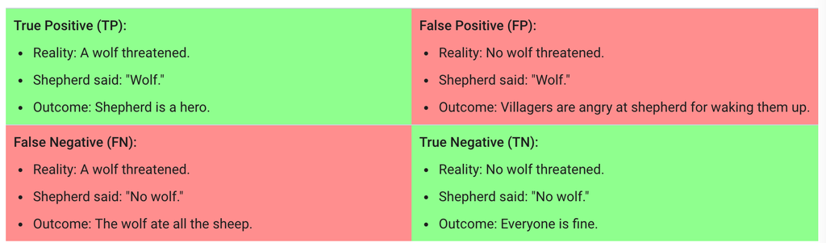

### Outcomes in binary classification

When performing **binary** classification, there are four possible outcomes.

(Note: A "positive prediction" is a prediction of 1, and a "negative prediction" is a prediction of 0.)

| Outcome of Prediction | Definition | True Class |
| --- | --- | --- |
| **True** positive (TP) ✅ | The predictor **correctly** predicts the positive class. | P |
| False negative (FN) ❌ | The predictor incorrectly predicts the negative class. | P |
| **True** negative (TN) ✅ | The predictor **correctly** predicts the negative class. | N |
| False positive (FP) ❌ | The predictor incorrectly predicts the positive class. | N |

⬇️

|  | Predicted Negative | Predicted Positive |
| --- | --- | --- |
| **Actually Negative** | TN ✅ | FP ❌ |
| **Actually Positive** | FN ❌ | TP ✅ |

*The **confusion matrix** above is organized the same way that `sklearn`'s confusion matrices are (but differently than in the wolf example).*

Note that in the four acronyms – TP, FN, TN, FP – the **first letter** is whether the prediction is correct, and the **second letter** is what the prediction is.

### Example: COVID testing 🦠

- UCSD Health administers hundreds of COVID tests a day. The tests are not fully accurate.
- Each test comes back either
  - positive, indicating that the individual has COVID, or
  - negative, indicating that the individual does not have COVID.
- **Question:** What is a TP in this scenario? FP? TN? FN?
- **TP:** The test predicted that the individual has COVID, and they do ✅.
- **FP:** The test predicted that the individual has COVID, but they don't ❌.
- **TN:** The test predicted that the individual doesn't have COVID, and they don't ✅.
- **FN:** The test predicted that the individual doesn't have COVID, but they do ❌.

### Accuracy of COVID tests

The results of 100 UCSD Health COVID tests are given below.

|  | Predicted Negative | Predicted Positive |
| --- | --- | --- |
| **Actually Negative** | TN = 90 ✅ | FP = 1 ❌ |
| **Actually Positive** | FN = 8 ❌ | TP = 1 ✅ |

*UCSD Health test results*

🤔 **Question:** What is the accuracy of the test?

**🙋 Answer:** $$\text{accuracy} = \frac{TP + TN}{TP + FP + FN + TN} = \frac{1 + 90}{100} = 0.91$$

- **Followup:** At first, the test seems good. But, suppose we build a classifier that predicts that **nobody has COVID**. What would its accuracy be?
- **Answer to followup:** Also 0.91! There is severe **class imbalance** in the dataset, meaning that most of the data points are in the same class (no COVID). Accuracy doesn't tell the full story.

### Recall

|  | Predicted Negative | Predicted Positive |
| --- | --- | --- |
| **Actually Negative** | TN = 90 ✅ | FP = 1 ❌ |
| **Actually Positive** | FN = 8 ❌ | TP = 1 ✅ |

*UCSD Health test results*

🤔 **Question:** What proportion of individuals who actually have COVID did the test **identify**?

**🙋 Answer:** $\frac{1}{1 + 8} = \frac{1}{9} \approx 0.11$

More generally, the **recall** of a binary classifier is the proportion of **actually positive instances** that are correctly classified. We'd like this number to be as close to 1 (100%) as possible.

$$\text{recall} = \frac{TP}{\text{# actually positive}} = \frac{TP}{TP + FN}$$

To compute recall, look at the **bottom (positive) row** of the above confusion matrix.

### Recall isn't everything, either!

$$\text{recall} = \frac{TP}{TP + FN}$$

🤔 **Question:** Can you design a "COVID test" with perfect recall?

**🙋 Answer:** Yes – **just predict that everyone has COVID!**

|  | Predicted Negative | Predicted Positive |
| --- | --- | --- |
| **Actually Negative** | TN = 0 ✅ | FP = 91 ❌ |
| **Actually Positive** | FN = 0 ❌ | TP = 9 ✅ |

*everyone-has-COVID classifier*

$$\text{recall} = \frac{TP}{TP + FN} = \frac{9}{9 + 0} = 1$$

Like accuracy, recall on its own is not a perfect metric. Even though the classifier we just created has perfect recall, it has 91 false positives!

### Precision

|  | Predicted Negative | Predicted Positive |
| --- | --- | --- |
| **Actually Negative** | TN = 0 ✅ | FP = 91 ❌ |
| **Actually Positive** | FN = 0 ❌ | TP = 9 ✅ |

*everyone-has-COVID classifier*

The **precision** of a binary classifier is the proportion of **predicted positive instances** that are correctly classified. We'd like this number to be as close to 1 (100%) as possible.

$$\text{precision} = \frac{TP}{\text{# predicted positive}} = \frac{TP}{TP + FP}$$

To compute precision, look at the **right (positive) column** of the above confusion matrix.

- **Tip:** A good way to remember the difference between precision and recall is that in the denominator for 🅿️recision, both terms have 🅿️ in them (TP and FP).
- Note that the "everyone-has-COVID" classifier has perfect recall, but a precision of $\frac{9}{9 + 91} = 0.09$, which is quite low.
- 🚨 **Key idea:** There is a "tradeoff" between precision and recall. Ideally, you want both to be high. For a particular prediction task, one may be important than the other.

### Precision and recall

[figure not shown]

([source](https://en.wikipedia.org/wiki/Precision_and_recall))

### Precision and recall

$$\text{precision} = \frac{TP}{TP + FP} \: \: \: \: \: \: \: \: \text{recall} = \frac{TP}{TP + FN}$$

### Question 🤔 (Answer at q.dsc80.com)

🤔 When might high **precision** be more important than high recall?

🤔 When might high **recall** be more important than high precision?

### Question 🤔 (Answer at q.dsc80.com)

Consider the confusion matrix shown below.

|  | Predicted Negative | Predicted Positive |
| --- | --- | --- |
| **Actually Negative** | TN = 22 ✅ | FP = 2 ❌ |
| **Actually Positive** | FN = 23 ❌ | TP = 18 ✅ |

What is the accuracy of the above classifier? The precision? The recall?

After calculating all three on your own, click below to see the answers.

**👉 Accuracy**

(22 + 18) / (22 + 2 + 23 + 18) = 40 / 65

**👉 Precision**

18 / (18 + 2) = 9 / 10

**👉 Recall**

18 / (18 + 23) = 18 / 41

## Summary, next time

### Summary

- Decision trees, while interpretable, are prone to having high variance. There are several ways to control the variance of a decision tree:
  - Limit `max_depth` or increase `min_samples_split`.
  - Create a random forest, which is an ensemble of multiple decision trees, each fit to a different random resample of the training data, using a random sample of features.
- In order to tune model hyperparameters – that is, to find the hyperparameters that likely maximize performance on unseen data – use `GridSearchCV`.
- Accuracy alone is not always a meaningful representation of a classifier's quality, particularly when the classes are imbalanced.
  - Precision and recall are classifier evaluation metrics that consider the types of errors being made.
  - There is a "tradeoff" between precision and recall. One may be more important than the other, depending on the task.